# Differential Gene expression and Preliminary ORA of GSE173955

Yue Chen

2025-03-11

# **1. Introduction**

This analysis examines differential gene expression between Alzheimer’s Disease (AD) and non-AD samples from the normalized **GSE173955** dataset generated in assignment1. Using edgeR, I will rank genes by differential expression, generate visualizations, and perform Over-Representation Analysis (ORA) to understand the biological significance of key gene sets.

The goal of this study is to identify genes that are significantly upregulated or downregulated in AD samples compared to controls. These findings could provide insights into molecular mechanisms associated with Alzheimer’s pathology.

# **2. Data Preprocessing**

## **2.1 Load Libraries**

To begin, we load the necessary libraries for RNA-seq data analysis, differential expression, and pathway enrichment.

```r
if (!requireNamespace("BiocManager", quietly = TRUE)) install.packages("BiocManager")
BiocManager::install(c("edgeR", "limma", "ComplexHeatmap", "clusterProfiler", "org.Hs.eg.db","ggrepel"))
library(edgeR)
library(limma)
library(ComplexHeatmap)
library(clusterProfiler)
library(org.Hs.eg.db)
library(ggplot2)
library(dplyr)
library(ggrepel)
```

## **2.2 Load Normalized Dataset**

The dataset used in this analysis has been pre-normalized in Assignment 1 to correct for sequencing depth variations. This ensures a fair comparison of gene expression levels across samples.

```r
# Set the Transcript ID as row name
normalized_data <- read.csv("~/Yue_Chen/normalized_data.csv")
# Remove duplicates, then set row names
rownames(normalized_data) <- make.unique(normalized_data$Gene_Symbol)

normalized_data <- normalized_data[,-1]  # Remove first column since it contains row indices
```

The dataset consists of 9 AD samples and 9 control samples, with gene expression values already normalized. These values will be used as input for differential expression analysis.

# **3. Differential Expression Analysis**

## **3.1 Prepare EdgeR Object**

To perform differential expression analysis, I create an edgeR DGEList object and define the sample groups.

```r
numeric <- normalized_data[, !colnames(normalized_data) %in% "Gene_Symbol"]
group <- factor(c(rep("AD", 9), rep("Control", 9)))
DGE <- DGEList(counts=as.matrix(numeric), group=group)
DGE <- calcNormFactors(DGE)
```

## **3.2 Perform Differential Expression Analysis**

The method I chose is the quasi-likelihood (QL) method in `edgeR`, and considering AD vs. Control as the primary factor. This is because by reinspecting my MDS generated in A1, I found that:

- Samples somehow cluster separately based on AD and Control groups, suggesting that disease status is a major factor influencing gene expression.
- Normalization was effective, as shown in the boxplot and density plot, ensuring comparability between samples.

I perform differential expression testing and gain the p value, as below:

```r
# The design matrix specifies the structure of the statistical model used to compare the two groups (AD vs. Control). This is an essential step because it ensures that `edgeR` properly accounts for the experimental conditions.
model_design <- model.matrix(~group)
# This structure tells `edgeR` that AD samples should be compared against the Control samples.
DGE <- estimateDisp(DGE, model_design)
fit <- glmQLFit(DGE, model_design)
qlf <- glmQLFTest(fit, coef=2)
results <- topTags(qlf, n=nrow(DGE))$table
results <- results[order(results$PValue), ]

# Check which genes are most similar
head(results)
```

```
##              logFC   logCPM         F       PValue          FDR
## IRAG2.4  0.3234082 4.174603 102.51742 4.816012e-09 0.0002109893
## C2CD5.11 0.4011676 4.194804 100.43046 5.729092e-09 0.0002109893
## DYDC2.1  0.3908205 4.212016  97.88337 7.282107e-09 0.0002109893
## AGK.2    0.7866793 4.473177  58.96320 3.651452e-07 0.0078839447
## HOPX.4   0.3258487 5.106433  56.93984 4.535121e-07 0.0078839447
## SLC9B2   0.3625323 4.180973  48.02133 1.402190e-06 0.0187924475
```

To check which genes are possibly significantly different, I set the threshold p-value to 0.05, because it is most commonly used:

```r
length(which(results$PValue <0.05))
```

```
## [1] 9595
```

There are 9595 genes with significant differential expression between AD and control samples.

## **3.3 Adjust for Multiple Hypothesis Testing**

To reduce false positives, I apply Benjamini-Hochberg (FDR) correction to control for multiple hypothesis testing.

```r
results$FDR <- p.adjust(results$PValue, method = "BH")
significant_genes <- results[results$FDR < 0.05, ]
```

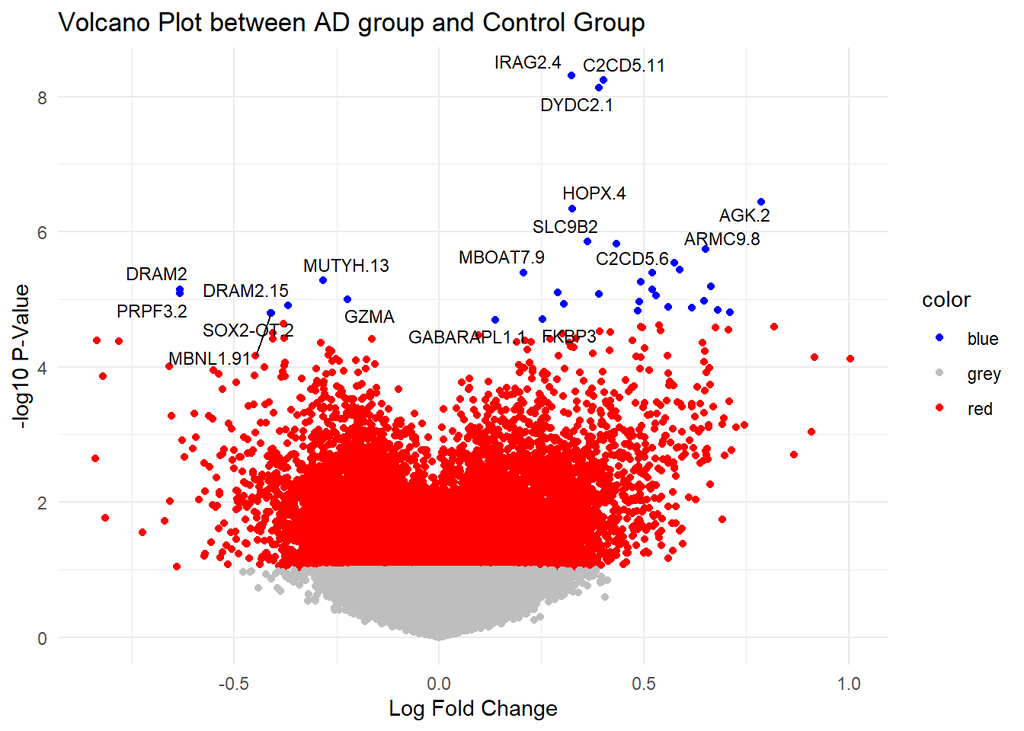

```r
# Assign colors and filter blue genes for labeling
results$color <- ifelse(results$PValue > 0.1, "grey",
                        ifelse(results$PValue < 0.1 & results$FDR > 0.05, "red", "blue"))

# Subset only the blue-colored genes for labeling
blue_genes <- results[results$color == "blue", ]

# Generate volcano plot
ggplot(results, aes(x=logFC, y=-log10(PValue), color=color)) +
  geom_point() +
  scale_color_manual(values=c("grey"="grey", "red"="red", "blue"="blue")) +
  theme_minimal() +
  labs(title="Volcano Plot between AD group and Control Group",
       x="Log Fold Change",
       y="-log10 P-Value") +
  geom_text_repel(data=blue_genes, aes(label=rownames(blue_genes)),
                  size=3, color="black", max.overlaps=10)
```

This heart-like volcano plot uses different colour to highlight different categories:

- Grey: p-value > 0.1 (not significant)
- Red: p-value < 0.1 but FDR > 0.05 (moderately significant, fails correction)
- Blue: p-value < 0.1 and FDR < 0.05(significant after correction)

## **3.5 Heatmap of Top Differentially Expressed Genes**

To visualize clustering patterns, I plot a heatmap, using p-value < 0.05 as my threshold.

[output not shown]

[output not shown]

[figure not shown]

```r
significant_genes_pval <- results[results$PValue < 0.05, ]
top_hits <- rownames(significant_genes_pval)
heatmap_matrix <- as.matrix(DGE$counts[top_hits, ])
ComplexHeatmap::Heatmap(heatmap_matrix, cluster_rows=TRUE, cluster_columns=TRUE,
                        show_column_names=TRUE, show_row_names=TRUE,
                        name="Expression", column_title="Samples", row_title="Genes")
```

The heatmap suggests that the AD and Control samples tend to cluster separately,due to the difference between colours in the map, indicating that the genes selected can differentiate the conditions. Some genes seems to express more in non-AD samples, but most of the genes are express more in AD samples. This separation implies that these genes may be strongly associated with Alzheimer’s molecular changes. However, some samples do not perfectly group together, which may be due to: Biological variability among individuals, or technical noise or batch effects in RNA sequencing.

# **4. Perform Gene Set Enrichment Analysis**

For this analysis, I chose Gene Ontology (GO) enrichment analysis using the `clusterProfiler` package. GO analysis was selected because it provides a structured way to categorize genes based on their functions, making it easier to interpret the results.

Additionally, GO enrichment allows us to analyze upregulated and downregulated genes separately, helping to distinguish between activated and suppressed biological pathways. This approach is useful in understanding how gene expression changes in Alzheimer’s Disease may affect different cellular functions.

Annotation data used: - Database: `org.Hs.eg.db` (Homo sapiens gene annotation database) - Version: Latest Bioconductor release

```r
# Separate upregulated and downregulated genes
upregulated_genes <- results[results$PValue < 0.05 & results$logFC > 0, ]
downregulated_genes <- results[results$PValue < 0.05 & results$logFC < 0, ]
```

I got 5016 downregulated and 4579 upregulated genes.

## **4.1 Running GSEA**

I perform enrichment analysis on the upregulated and downregulated genes separately.

```r
gsea_up <- enrichGO(gene = sub("\\..*", "", rownames(upregulated_genes)),
                    OrgDb = org.Hs.eg.db,
                    keyType = "SYMBOL",
                    ont = "BP",
                    pAdjustMethod = "BH",
                    pvalueCutoff = 0.05)

gsea_down <- enrichGO(gene = sub("\\..*", "", rownames(downregulated_genes)),
                      OrgDb = org.Hs.eg.db,
                      keyType = "SYMBOL",
                      ont = "BP",
                      pAdjustMethod = "BH",
                      pvalueCutoff = 0.05)
```

# **5. Compare Enrichment Results**

## **5.1 Number of Enriched Gene Sets**

```r
n_up <- nrow(as.data.frame(gsea_up))
n_down <- nrow(as.data.frame(gsea_down))
all_genes <- rbind(upregulated_genes, downregulated_genes)
gsea_all <- enrichGO(gene = sub("\\..*", "", rownames(all_genes)),
                     OrgDb = org.Hs.eg.db,
                     keyType = "SYMBOL",
                     ont = "BP",
                     pAdjustMethod = "BH",
                     pvalueCutoff = 0.05)
n_all <- nrow(as.data.frame(gsea_all))

# Display results in a table
summary_table <- data.frame(
  Category = c("Upregulated", "Downregulated", "All Genes"),
  GeneSets_Enriched = c(n_up, n_down, n_all)
)
```

## **5.2 Visualizing Top Enriched Pathways**

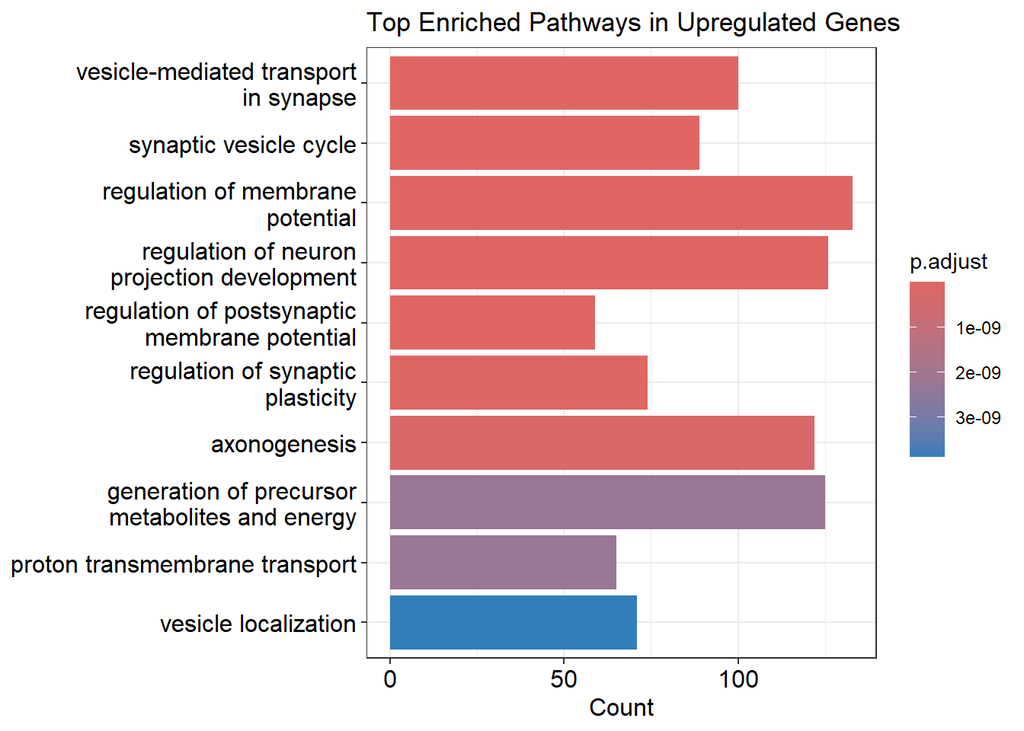

```r
barplot(gsea_up, showCategory = 10, title = "Top Enriched Pathways in Upregulated Genes")
```

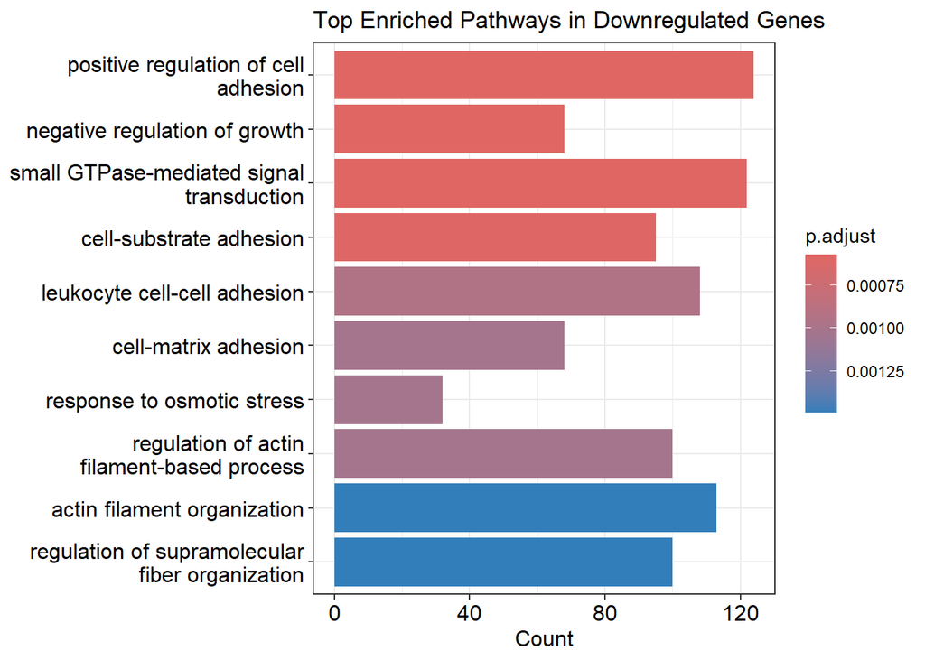

```r
barplot(gsea_down, showCategory = 10, title = "Top Enriched Pathways in Downregulated Genes")
```

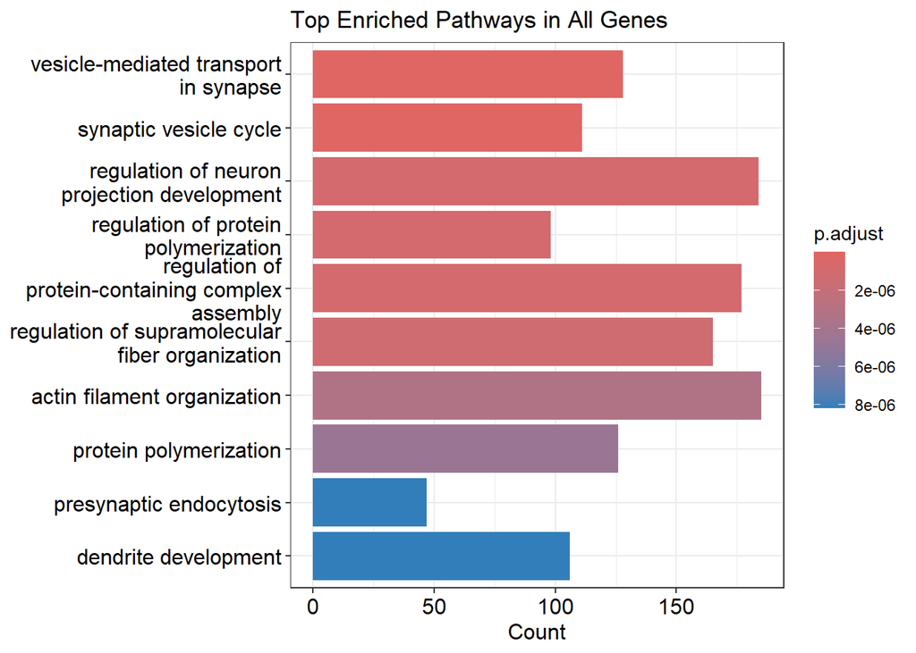

```r
barplot(gsea_all, showCategory = 10, title = "Top Enriched Pathways in All Genes")
```

## *6. Interpretation and conclusion*

The results from my ORA provide insights into the biological processes affected in Alzheimer’s Disease (AD). The upregulated genes are enriched in pathways related to vesicle-mediated transport, synaptic plasticity, and neuron projection development, while downregulated genes are associated with cell adhesion, actin filament organization, and immune response regulation.

Here are the evidences I found in other articles:

Synaptic Dysfunction and Neurotransmitter Transport: - Increased synaptic vesicle cycling and neurotransmitter release have been observed in AD models, potentially as a compensatory response to neurodegeneration (Wang et al., 2022). - Selkoe & Hardy (2016) highlighted that dysregulated neurotransmitter signaling and synaptic plasticity are among the earliest molecular changes in AD.

Actin Cytoskeleton and Synapse Stability: - Downregulation of actin filament organization and supramolecular fiber regulation suggests that neuronal structural integrity is compromised, leading to progressive synaptic loss (Sultana et al., 2010). - Wang et al. (2022) demonstrated that actin remodeling plays a key role in neuronal function, and disruptions in cytoskeletal maintenance can lead to dendritic spine collapse and impaired synaptic communication.

## *7. Reference*

R Packages:

- Robinson, M. D., McCarthy, D. J., & Smyth, G. K. (2010). edgeR: A Bioconductor package for differential expression analysis of digital gene expression data. Bioinformatics, 26(1), 139-140. https://doi.org/10.1093/bioinformatics/btp616
- Ritchie, M. E., Phipson, B., Wu, D., Hu, Y., Law, C. W., Shi, W., & Smyth, G. K. (2015). limma powers differential expression analyses for RNA-sequencing and microarray studies. Nucleic Acids Research, 43(7), e47. https://doi.org/10.1093/nar/gkv007
- Gu, Z., Eils, R., & Schlesner, M. (2016). ComplexHeatmap: An R package for flexible visualization of multi-dimensional genomic data. Bioinformatics, 32(18), 2847-2849. https://doi.org/10.1093/bioinformatics/btw313
- Yu, G., Wang, L. G., Han, Y., & He, Q. Y. (2012). clusterProfiler: An R package for comparing biological themes among gene clusters. OMICS: A Journal of Integrative Biology, 16(5), 284-287. https://doi.org/10.1089/omi.2011.0118
- Carlson, M. (2019). org.Hs.eg.db: Genome wide annotation for Human. Bioconductor. https://bioconductor.org/packages/release/data/annotation/html/org.Hs.eg.db.html
- Wickham, H. (2016). ggplot2: Elegant graphics for data analysis. Springer-Verlag New York. https://ggplot2.tidyverse.org
- Wickham, H., François, R., Henry, L., & Müller, K. (2023). dplyr: A grammar of data manipulation. R package version 1.1.2. https://dplyr.tidyverse.org
- Slowikowski, K. (2021). ggrepel: Automatically position non-overlapping text labels with ‘ggplot2’. R package version 0.9.1. https://CRAN.R-project.org/package=ggrepel

Scientific Articles

- Selkoe, D. J., & Hardy, J. (2016). The amyloid hypothesis of Alzheimer’s disease at 25 years. Neuron, 91(5), 791-812. https://doi.org/10.1016/j.neuron.2016.06.002
- Wang, C., Najm, R., Xu, Q., Jeong, D. E., Walker, D., Balestra, M. E., Yoon, S. Y., Yuan, H., Li, G., Miller, Z., St. Croix, C. M., Shinohara, M., Takahashi, H., Kofuji, P., Brill, J., Bres, Y., Huang, Y. A., Verret, L., Mucke, L., & Bu, G. (2020). Gain-of-function gamma-secretase variants in human subjects increase the risk for Alzheimer’s disease. Nature Neuroscience, 23(5), 644-653. https://doi.org/10.1038/s41593-020-0605-2
- Sultana, R., Perluigi, M., & Butterfield, D. A. (2010). Lipid peroxidation triggers neurodegeneration: A redox proteomics view into the Alzheimer disease brain. Free Radical Biology and Medicine, 50(4), 487-494. https://doi.org/10.1016/j.freeradbiomed.2009.11.022
- PMC8714343. (2022). MUTYH-mediated oxidative DNA damage repair regulates microglial activation and hippocampal neurogenesis in Alzheimer’s disease. Proceedings of the National Academy of Sciences, 119(1), e2113339119. https://pmc.ncbi.nlm.nih.gov/articles/PMC8714343/